# Ch.8 Exercises: Tree Based Methods

# Conceptual excercises

**(3)**

```r
pm = 0.05*(1:20)
g = 2*pm*(1-pm)
d = -pm*log(pm) - (1-pm)*log((1-pm))
e = pmin(pm, 1-pm)
plot(x=pm, g, col="blue", ylim=c(0, 1))
lines(x=pm, d, col="red")
```

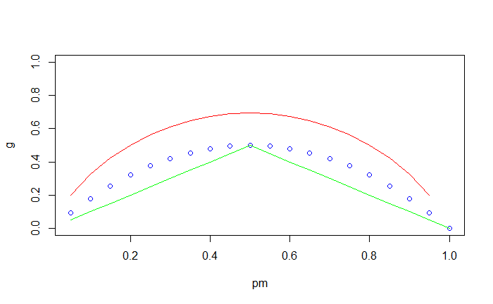

```r
lines(x=pm, e, col="green")
```

# Applied exercises

```r
attach(Boston)
library(tree)
library(randomForest)
require(caTools)
set.seed(1)
```

**(7)** for loop over m for loop over ntrees increasing by 10 each time split with sample into (caTools) test and train set calculate test errors for each case (matrix of errors) add lines to plot with different colors (rainbow)

```r
# split test and train set
train = sample(1:nrow(Boston), nrow(Boston)*0.8)
Boston.test = Boston[,-train]
```

```r
m.range = seq(1,13,by=1)

ntree.range = c(1, seq(5,100, by=10))
rf.mse = matrix(nrow=length(ntree.range), ncol=length(m.range))

for (m in m.range){
  for (n in 1:length(ntree.range)){
    rf.fit = randomForest(medv~., data=Boston, subset=train, mtry=m, ntree=ntree.range[n])
    rf.pred = predict(rf.fit, newdata=Boston.test)

    rf.mse[n, m] = mean((Boston.test$medv-rf.pred)**2)
  }
}
```

```r
#plot results
library(tidyr)
colors = rainbow(length(m.range))

#dev.new(width = 1000, height = 500, unit = "px",noRStudioGD = TRUE)
plot(x=ntree.range, y=rf.mse[,1], col=colors[1], type='l', xlab='Number of Trees', ylab='Test MSE', lwd=2, ylim=c(5,50), )
for (i in 2:length(m.range)){
  lines(x=ntree.range, y=rf.mse[,i], col=colors[i], type='l', lwd=2)
}
```

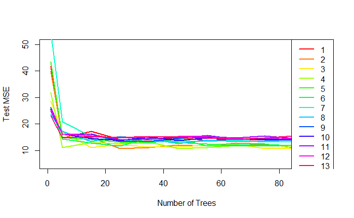

```r
legend("topright",legend=m.range,
       col=colors,lty=rep(1, length(m.range)), lwd=rep(2, length(m.range)))
```

**(8)**

```r
detach(Boston)
attach(Carseats)
```

**(a)**

```r
# split test and train set
train = sample(1:nrow(Carseats), nrow(Carseats)*0.8)
Carseats.test = Carseats[-train,]
```

**(b)**

```r
set.seed(1)
tree.fit = tree(Sales~., data=Carseats, subset=train)
tree.preds = predict(tree.fit, newdata=Carseats.test)
test_mse = mean((tree.preds-Carseats.test$Sales)**2)
summary(tree.fit)
```

```
Regression tree:
tree(formula = Sales ~ ., data = Carseats, subset = train)
Variables actually used in tree construction:
[1] "ShelveLoc"   "Price"       "CompPrice"   "Advertising" "Population"  "Education"
Number of terminal nodes:  17
Residual mean deviance:  2.58 = 781.7 / 303
Distribution of residuals:
    Min.  1st Qu.   Median     Mean  3rd Qu.     Max.
-4.47800 -0.99750 -0.06495  0.00000  1.08800  3.87200
```

```r
test_mse
```

```
[1] 3.836154
```

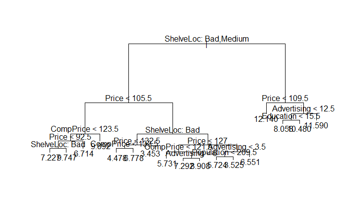

```r
plot(tree.fit)
text(tree.fit, pretty=0)
```

ShelveLoc and Price look to be the most significant variables. Test Mse = 3.83

**(c)**

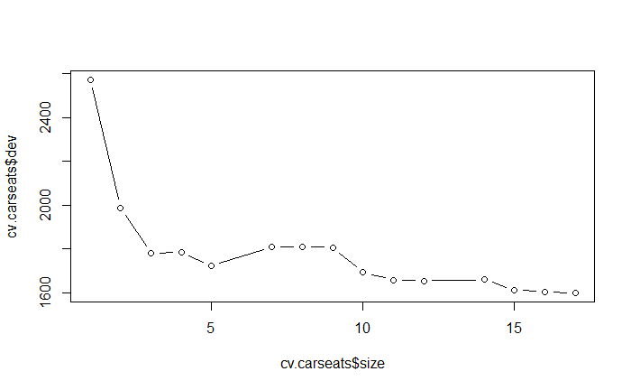

```r
cv.carseats = cv.tree(tree.fit)
plot(cv.carseats$size, cv.carseats$dev, type='b')
```

The most complex tree (17 nodes) is selected with crossvalidation

if we would want to prune the tree, we can do so like this:

```r
prune.carseats = prune.tree(tree.fit, best=12)
tree.preds = predict(prune.carseats, newdata=Carseats.test)
test_mse = mean((tree.preds-Carseats.test$Sales)**2)
test_mse
```

```
[1] 3.736466
```

**(d)**

```r
bag.carseats = randomForest(Sales~., data=Carseats, subset=train, mtry=dim(Carseats)[2]-1, importance=TRUE)

yhat.bag = predict(bag.carseats, newdata=Carseats.test)
test.mse = mean((yhat.bag-Carseats.test$Sales)**2)

test.mse
```

```
[1] 2.047928
```

```r
summary(bag.carseats)
```

```
                Length Class  Mode
call              6    -none- call
type              1    -none- character
predicted       320    -none- numeric
mse             500    -none- numeric
rsq             500    -none- numeric
oob.times       320    -none- numeric
importance       20    -none- numeric
importanceSD     10    -none- numeric
localImportance   0    -none- NULL
proximity         0    -none- NULL
ntree             1    -none- numeric
mtry              1    -none- numeric
forest           11    -none- list
coefs             0    -none- NULL
y               320    -none- numeric
test              0    -none- NULL
inbag             0    -none- NULL
terms             3    terms  call
```

```r
importance(bag.carseats)
```

```
              %IncMSE IncNodePurity
CompPrice   30.276930     247.33526
Income      13.401781     146.84804
Advertising 27.167040     209.57278
Population   0.458302      77.78121
Price       77.441078     772.12988
ShelveLoc   75.028947     725.35736
Age         21.247395     207.70880
Education    3.041850      69.37722
Urban       -1.896493      12.76105
US           1.069598       9.30272
```

variable importance shows that ShelveLoc and Price are the most important by far.

**(e)**

```r
m.range = seq(1,dim(Carseats)[2]-1,by=1)
rf.mse = rep(NA, length(m.range))

for (m in m.range){

  rf.fit = randomForest(Sales~., data=Carseats, subset=train, mtry=m, ntree=500)
  rf.pred = predict(rf.fit, newdata=Carseats.test)

  rf.mse[m] = mean((Carseats.test$Sales-rf.pred)**2)

}
```

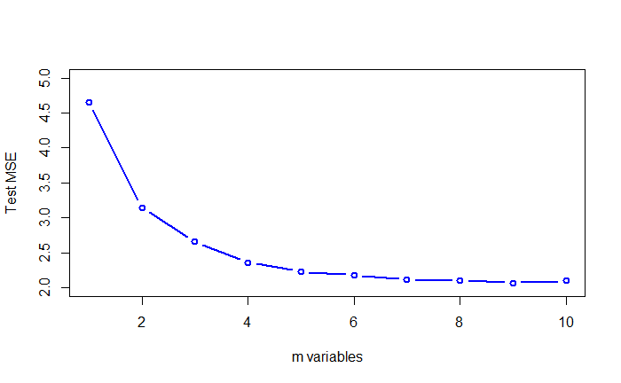

```r
#plot results
colors = rainbow(length(m.range))

plot(x=m.range, y=rf.mse, col="blue", type='b', xlab='m variables', ylab='Test MSE', lwd=2, ylim=c(2,5), )
```

increasing m for random forests decreases the test MSE until we reach the bagging mse where m=p

```r
which.min(rf.mse)
```

```
[1] 9
```

```r
rf.fit = randomForest(Sales~., data=Carseats, subset=train, mtry=4, ntree=500, importance=TRUE)
rf.pred = predict(rf.fit, newdata=Carseats.test)

mean((Carseats.test$Sales-rf.pred)**2)
```

```
[1] 2.384836
```

```r
importance(rf.fit)
```

```
               %IncMSE IncNodePurity
CompPrice   20.4280367     228.69239
Income       7.1168616     183.80694
Advertising 19.7066196     230.83313
Population  -1.8412738     125.79482
Price       55.4363383     698.40604
ShelveLoc   55.1527623     621.04919
Age         18.0956614     235.21003
Education    0.5493878      92.18535
Urban       -0.9568251      18.77759
US           1.3590159      22.33683
```

**(9)**

```r
detach(Carseats)
attach(OJ)
```

**(a)**